# MScA, Bayesian Methods (32014) Week 4 Workshop

Yuri Balasanov, © iLykei 2016

# 1 References

[G] Andrew Gelman, John B. Carlin, Hal S. Stern, David B. Dunson, Aki Vehtari, Donald B. Rubin, Bayesian Data Analysis, Third Edition, 2013, Taylor & Francis Group.  
[K] John K. Kruschke, Doing Bayesian Data Analysis, A Tutorial with R, JAGS, and STAN, 2015, Elsevier.

# 2 Multidimensional Spaces and MCMC

Multidimensional spaces look strange!

[Cross Section of the Quintic Calabi-Yau Manifold](http://bugman123.com/Physics/Calabi-Yau.m1v)

In order to explore such spaces one needs MMC rather than independent Monte Carlo sampling.

The original uploader was Vzografos at English Wikipedia

# 3 Metropolis Algorithm

Create a function that makes decision for one step of Metropolis random walk based on the initial state and vector of probabilities.  
Set vector of probabilities, for example:

```r
probabilities<-c(.1,.3,.5,.05,.05)
sum(probabilities)
```

```
## [1] 1
```

```r
init<-2
```

Repeat 100 000 steps and use the simulated trajectory to estimate probabilities of each state.  
Compare these proportions with the defined probabilities.

(Do it yourself)

```r
oneStep<-function(initSt,probabilities){
  numberStates<-length(probabilities)
  turn<-sample(c(-1,1),1)
  newStates<-c(initSt, initSt+turn)
  if (newStates[2]==numberStates+1) newStates[2]<-1
  if (newStates[2]==0) newStates[2]<-numberStates
  if (probabilities[newStates[2]]>probabilities[newStates[1]]) {
    res<-newStates[2]
  } else {
    p<-probabilities[newStates[2]]/probabilities[newStates[1]]
    res<-sample(newStates,1,prob = c(1-p,p))
  }
  res
}

trajectory<-rep(NA,100000)
for (i in 1:100000){
init<-oneStep(init,probabilities)
trajectory[i]<-init
}
table(trajectory)
```

```
## trajectory
##     1     2     3     4     5
## 10123 30245 49673  4947  5012
```

```r
table(trajectory)/sum(table(trajectory))
```

```
## trajectory
##       1       2       3       4       5
## 0.10123 0.30245 0.49673 0.04947 0.05012
```

# 4 Using JAGS to Estimate Binomial Probability

## 4.1 Data

Download file with R code from [web site of John Kruschke, file DBDA2Eprograms.zip](https://sites.google.com/site/doingbayesiandataanalysis/software-installation).

Follow installation instructions for the software in the book, JAGS and STAN.

When use the code from the book always make the folder with all files archived in DBDA2Eprograms.zip the working directory.

A binomial sample is given in the file “z15N50.csv” from the site of [K]

```r
suppressWarnings(source(paste(dataPath,"DBDA2E-utilities.R",sep="/")))
```

```
##
## Kruschke, J. K. (2015). Doing Bayesian Data Analysis, Second Edition:
## A Tutorial with R, JAGS, and Stan. Academic Press / Elsevier.
```

```r
myData<-read.csv(paste(dataPath,"z15N50.csv",sep="/"))
head(myData)
```

```
##   y
## 1 0
## 2 1
## 3 0
## 4 0
## 5 0
## 6 0
```

```r
y<-myData$y
(Ntotal<-length(y))
```

```
## [1] 50
```

```r
(dataList<-list(y=y,Ntotal=Ntotal))
```

```
## $y
##  [1] 0 1 0 0 0 0 0 0 0 0 1 0 0 0 1 1 1 0 0 1 0 0 0 0 1 1 0 0 0 0 0 1 0 1 0
## [36] 1 0 0 0 1 0 0 1 1 0 1 0 0 0 0
##
## $Ntotal
## [1] 50
```

Such formatted data will be sent to JAGS server for analysis.

## 4.2 Preparation of the model for JAGS

In order to prepare the model, first, clarify its structure for yourself.  
It is useful to do it by creating a diagram, like in [K].  
A tool for making such diagrams can be downloaded [here](http://doingbayesiandataanalysis.blogspot.com/2013/10/diagrams-for-hierarchical-models-new.html).

Interpretation of the diagram starts from the bottom.  
Each arrow of the diagram corresponds to a line of description code for the model.

Line 1 of the model describes generation of the data according to the likelihood function: $y_i \sim dbern(\theta)$.  
Line 2 of the model describes generation of the parameter $\theta$ from the prior distribution: $\theta \sim dbeta(\alpha,\beta)$.  
In this case parameters of the prior distribution should be defined. For example, $\alpha = \beta = 1$.  
The format of the model description for JAGS is a string:

```r
modelString="
model {
  for (i in 1:Ntotal) {
    y[i]~dbern(theta)
  }
  theta~dbeta(1,1)
}
"
```

Note that variables names `y` and `Ntotal` match the names of the list of the data.  
The syntax of the model description is `model{description}`.

The next step of preparation of the model description for JAGS is saving it to a temporary text file `Tempmodel`.

```r
writeLines(modelString,con="Tempmodel.txt")
```

## 4.3 Initializing Markov chains

Performance of MCMC will greatly depend on initial values of random walks.  
Some sources recommend dispersing starting values of different trajectories as far from each other as possible to guarantee good convergence and reliable estimation of time such convergence **burn in period**.  
Other sources, including [K] recommend randomly concentrating them around MLE.  
Probably, each approach may be good depending on properties of the model and complexity of the data.  
For simple enough models when convergence is not expected to be an issue, pointing trajectories to the neighborhood of MLE may improve time of simulation.  
In more complex cases it might be better to allow longer burn in period in exchange for good convergence check.

One way of initializing trajectories is to define a list of lists with their values. Alternative way is creating a function that returns an init value every time it is called. JAGS will call this function every time it starts a new chain:

```r
MLE<-sum(y)/Ntotal
init1<-MLE
init2<-MLE*(1+.01)
init3<-MLE*(1-.01)
initsList<-function(){
  thetaInit<-sample(c(init1,init2,init3),1,replace=T)
  return(list(theta=thetaInit))
}
initsList()
```

```
## $theta
## [1] 0.303
```

## 4.4 Sending information to JAGS

Next step is getting all information to JAGS using `jags.model()` from library `rjags`.  
This function transfers the data, the model specification and the initial values to JAGS and requests JAGS to select appropriate sampling method.

```r
library(rjags)
jagsModel<-jags.model(file="TempModel.txt",data=dataList,n.chains=3,n.adapt=500)
names(jagsModel)
```

```
## [1] "ptr"       "data"      "model"     "state"     "nchain"    "iter"
## [7] "sync"      "recompile"
```

In `jags.model` parameter `n.chains` specifies the number of chains to run (defaults to 1) and parameter `n.adapt` sets the number of steps JAGS can take to tune the sampling method (defaults to 1000).

The object returned by `jags.model` contains all information that we need to communicate to JAGS about the problem in the format suitable for JAGS.

## 4.5 Running MCMC on JAGS: burn in and main run

Now run JAGS chains for 600 steps to complete burn in, i.e. transition to a stable distribution of Markov chain.

```r
update(jagsModel,n.iter=600)
```

After completing burn in generate MCMC trajectories representing the posterior distribution for the model.

```r
codaSamples<-coda.samples(jagsModel,variable.names=c("theta"),n.iter=3334)
list.samplers(jagsModel)
```

```
## $`bugs::ConjugateBeta`
## [1] "theta"
```

```r
head(codaSamples)
```

```
## [[1]]
## Markov Chain Monte Carlo (MCMC) output:
## Start = 601
## End = 607
## Thinning interval = 1
##          theta
## [1,] 0.2549247
## [2,] 0.3634651
## [3,] 0.2652512
## [4,] 0.2545412
## [5,] 0.1982097
## [6,] 0.2285682
## [7,] 0.2489259
##
## [[2]]
## Markov Chain Monte Carlo (MCMC) output:
## Start = 601
## End = 607
## Thinning interval = 1
##          theta
## [1,] 0.3013679
## [2,] 0.2636627
## [3,] 0.4172230
## [4,] 0.2678113
## [5,] 0.3582251
## [6,] 0.3156554
## [7,] 0.3170301
##
## [[3]]
## Markov Chain Monte Carlo (MCMC) output:
## Start = 601
## End = 607
## Thinning interval = 1
##          theta
## [1,] 0.3871979
## [2,] 0.4487389
## [3,] 0.2538401
## [4,] 0.2759216
## [5,] 0.2531728
## [6,] 0.2722686
## [7,] 0.2664991
##
## attr(,"class")
## [1] "mcmc.list"
```

Besides the model specification object `coda.samples()` takes a vector of character strings corresponding to the names of parameters to record `variable.names` and the number of iterations to run `n.iter`.  
In this example there are 3 chains, to the total number of iterations will be about 10,000.

Use function `list.samplers` to show the samplers applied to the model.

## 4.6 Analyzing the results

```r
summary(codaSamples)
```

```
##
## Iterations = 601:3934
## Thinning interval = 1
## Number of chains = 3
## Sample size per chain = 3334
##
## 1. Empirical mean and standard deviation for each variable,
##    plus standard error of the mean:
##
##           Mean             SD       Naive SE Time-series SE
##      0.3081546      0.0639327      0.0006393      0.0006392
##
## 2. Quantiles for each variable:
##
##   2.5%    25%    50%    75%  97.5%
## 0.1881 0.2631 0.3063 0.3504 0.4404
```

The “naive” standard error is the standard error of the mean, which captures simulation error of the mean rather than posterior uncertainty.
$$naive~SE=\frac{posterior~SD}{\sqrt n}.$$

The time-series standard error adjusts the “naive” standard error for autocorrelation.

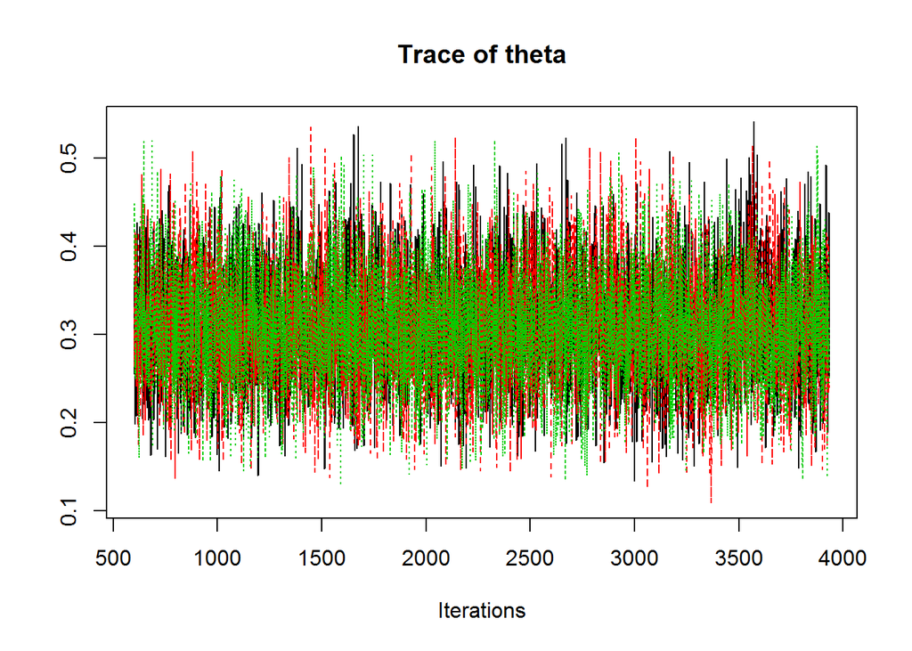

```r
coda::traceplot(codaSamples)
```

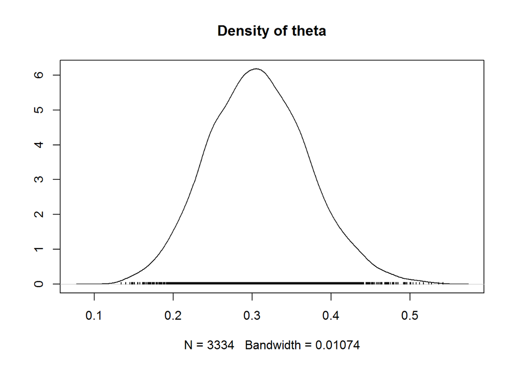

```r
densplot(codaSamples)
```

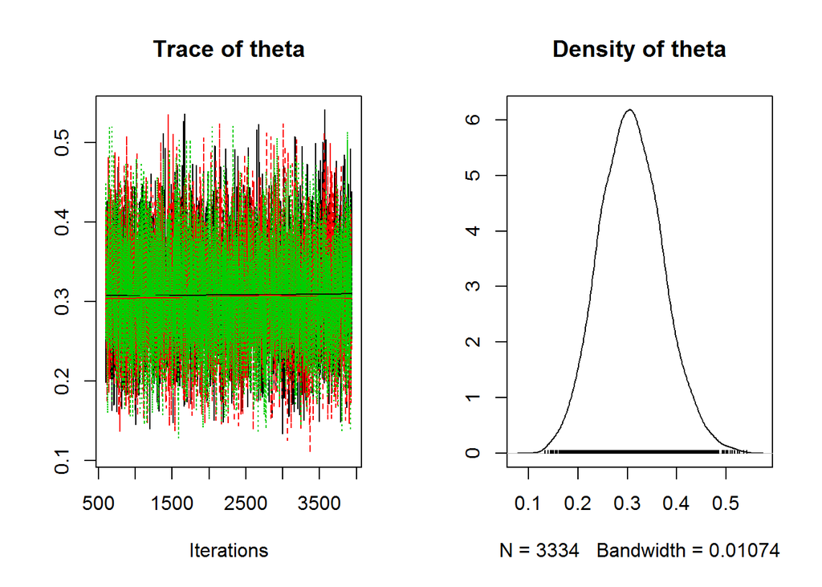

```r
plot(codaSamples)
```

Function `traceplot()` and `densplot()` show characteristics of the chains for each parameter; `plot()` shows the combination of both.

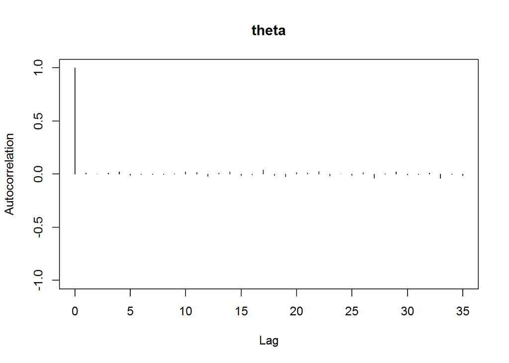

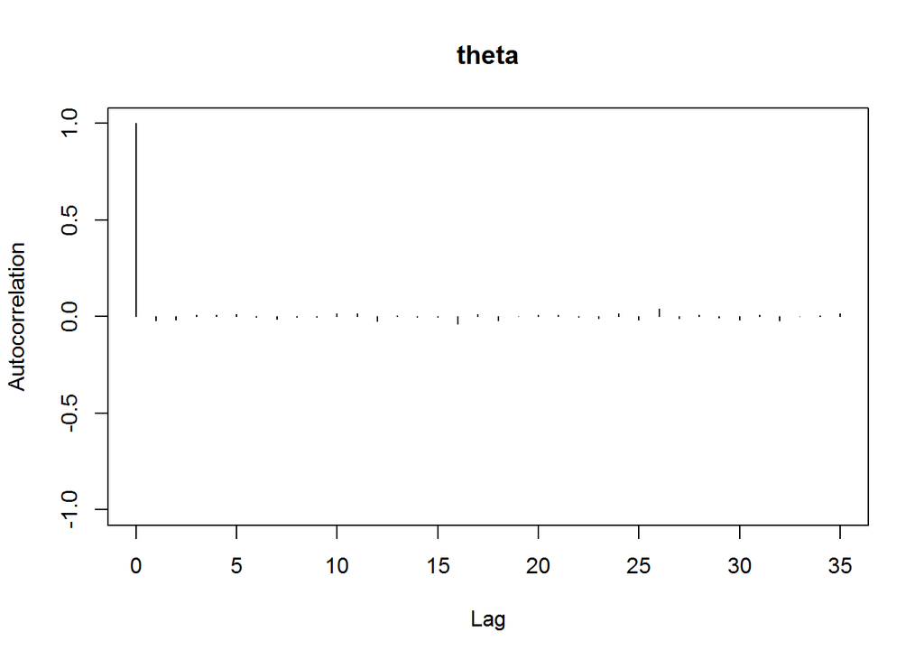

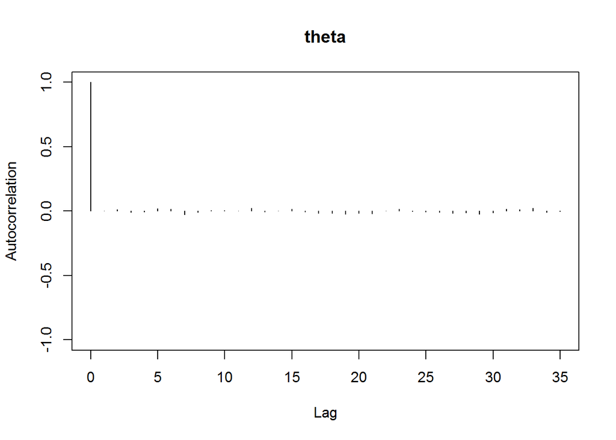

```r
autocorr.plot(codaSamples,ask=F)
```

Autocorrelation function plot shows autocorrelations for different lags of the chains.

One measure based on autocorrelation function, called **effective sample size (ESS)** shows the size of the sample one would need to run to get a completely non-autocorrelated chain.
$$ESS=\frac{n}{(1+2\sum_k ACF(k))}.$$
The infinite sum usually stops when $ACF(k)<0.05$
In the best case scenario there is no autocorrelation in the chains and $ESS$ is the same as the combined length of the simulated chains.
If there is a nonzero autocorrelation at lags up until $k$ then the chain samples have to be thinned to leave $k$ observations between consecutive values. This reduces $ESS$.

```r
effectiveSize(codaSamples)
```

```
## theta
## 10002
```

The $ESS$ number is consistent with the autocorrelation function.

Potential scale reduction factor or shrink factor introduced by Gelman is returned by `gelman.diag()`.

```r
gelman.diag(codaSamples)
```

```
## Potential scale reduction factors:
##
##       Point est. Upper C.I.
## theta          1          1
```

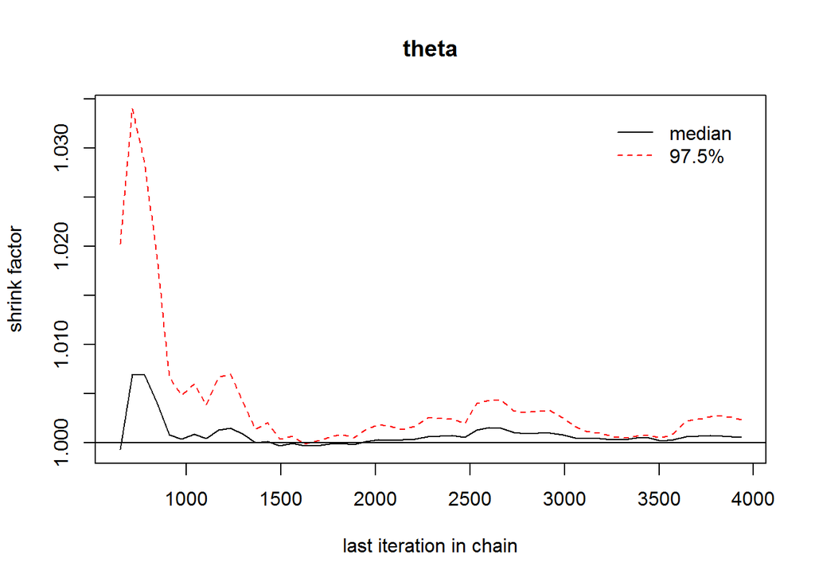

```r
gelman.plot(codaSamples)
```

Output of Gelman diagnostic contains the shrink factor and its upper 95% confidence level.

Gelman diagnostic measure called **shrink factor** is based on comparison of within chain variance and between chain variance.

Let $\theta_{i,j}$ be the $i^{th}$ sample of $j^{th}$ chain, $i=1,\ldots,n;j=1,\ldots,m$.
Then variance of chain $j$ is
$$s_j^2=\frac{1}{n-1}\sum_{i=1}^n(\theta_{i,j}-\bar{\theta}_j)^2.$$
Average variance over $m$ chains is
$$\bar{s}^2=\frac{1}{m}\sum_{j=1}^m s_j^2.$$
Variable $\bar{s}^2$ is called **within chain variance**.

Also define **between chain variance** as
$$\bar{S}^2=\frac{n}{m-1}\sum_{j=1}^m (\bar{\theta}_j-\bar{\theta})^2,$$
$$\bar{\theta}=\frac{1}{m}\sum_{j=1}^m \bar{\theta}_j.$$

Then estimated variance of stationary distribution is
$$\hat{V}(\theta)=(1-\frac{1}{n})\bar{s}^2+\frac{1}{n}\bar{S}^2$$

Finally, Gelman measure of convergence called **shrink factor** is
$$R=\sqrt{\frac{\hat{V}(\theta)}{\bar{s}^2}}.$$

If $R$ is high (rule of thumb is $R>1.1$) then convergence is not sufficient and chains should be made longer.

Finally, find the mean values of posterior distributions corresponding to different chains:

```r
lapply(codaSamples,mean)
```

```
## [[1]]
## [1] 0.3098207
##
## [[2]]
## [1] 0.3071794
##
## [[3]]
## [1] 0.3074637
```

```r
sum(y)/Ntotal
```

```
## [1] 0.3
```

Compare the posterior densities generated by 3 chains with theoretical posterior distribution:

```r
(l<-min(unlist(codaSamples))-.05)
```

```
## [1] 0.05880454
```

```r
(h<-max(unlist(codaSamples))+.05)
```

```
## [1] 0.5914174
```

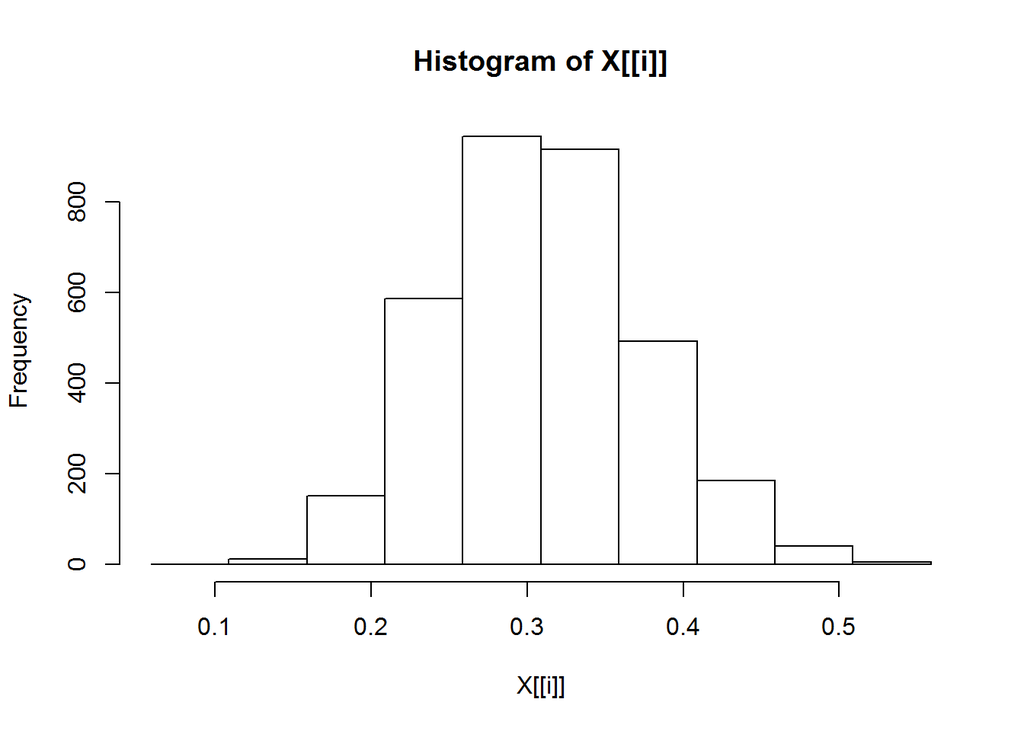

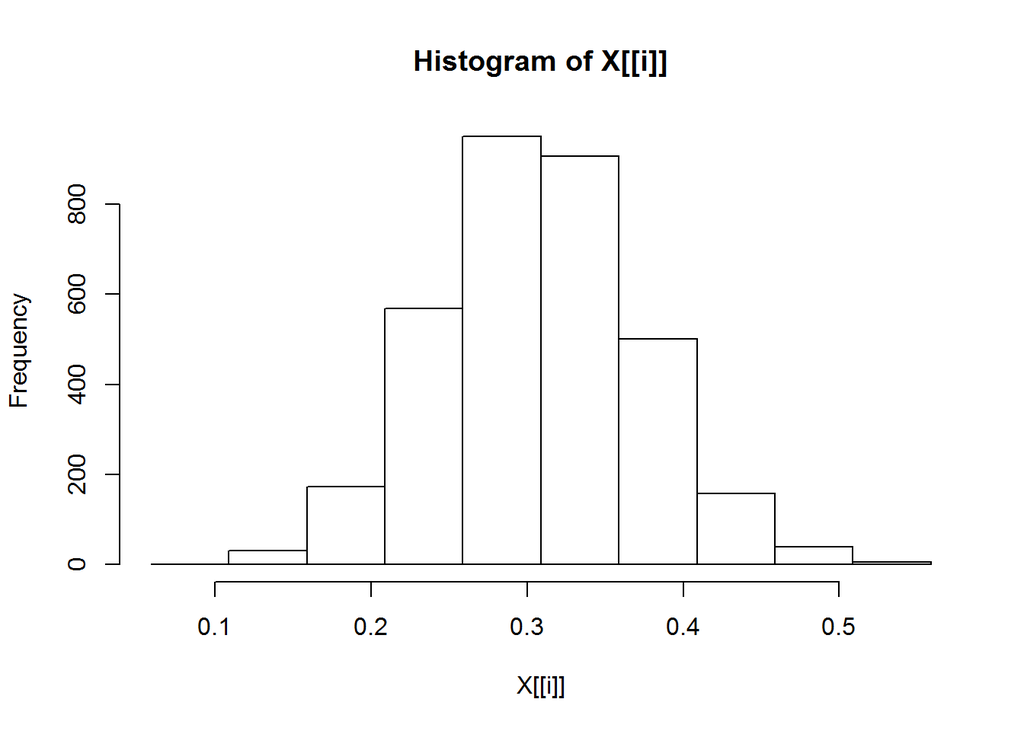

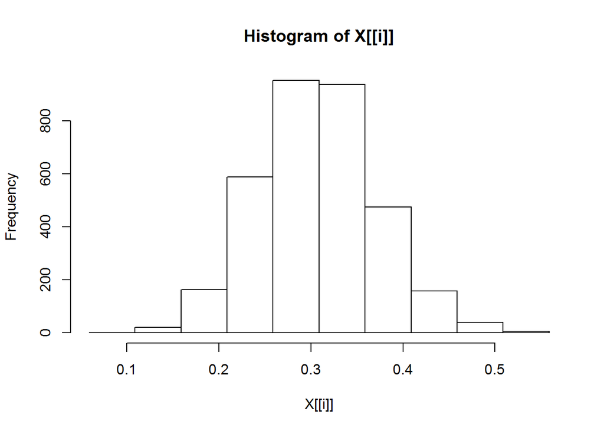

```r
histBreaks<-seq(l,h,by=.05)
postHist<-lapply(codaSamples,hist,breaks=histBreaks)
```

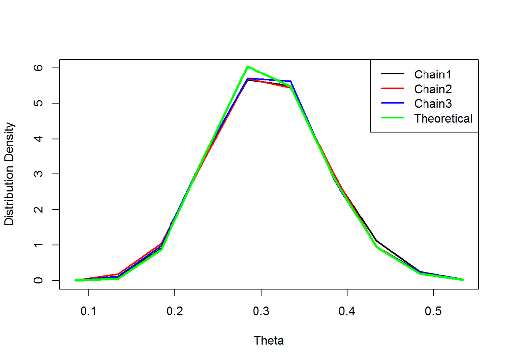

```r
plot(postHist[[1]]$mids,postHist[[1]]$density,type="l",col="black",lwd=2,ylim=c(0,6),ylab="Distribution Density",xlab="Theta")
lines(postHist[[2]]$mids,postHist[[2]]$density,type="l",col="red",lwd=2)
lines(postHist[[3]]$mids,postHist[[3]]$density,type="l",col="blue",lwd=2)
lines(postHist[[3]]$mids,dbeta(postHist[[3]]$mids,1+sum(y),Ntotal-sum(y)+1),type="l",col="green",lwd=3)
legend("topright",legend=c("Chain1","Chain2","Chain3","Theoretical"),col=c("black","red","blue","green"),lwd=2)
```

# 5 Comparison of two binomial distributions

Consider a more realistic model now: two groups of patients are selected and given two treatments, one of which is a placebo.

## 5.1 Data

Download data, prepare them for JAGS.  
Select parameters of beta prior distribution.

```r
myData<-read.csv(paste(dataPath,"2GroupsStudy.csv",sep="/"))
(y=myData$y)
```

```
##  [1] 1 0 1 1 1 1 1 0 0 0 1 0 0 1 0
```

```r
(s<-as.numeric(myData$s))
```

```
##  [1] 2 2 2 2 2 2 2 2 1 1 1 1 1 1 1
```

```r
(Ntotal<-length(y))
```

```
## [1] 15
```

```r
(Nsubj<-length(unique(s)))
```

```
## [1] 2
```

```r
(dataList<-list(y=y,s=s,Ntotal=Ntotal,Nsubj=Nsubj))
```

```
## $y
##  [1] 1 0 1 1 1 1 1 0 0 0 1 0 0 1 0
##
## $s
##  [1] 2 2 2 2 2 2 2 2 1 1 1 1 1 1 1
##
## $Ntotal
## [1] 15
##
## $Nsubj
## [1] 2
```

## 5.2 Different group proportions, common prior

### 5.2.1 Model preparation

Prepare the model string. It will be saved in the work directory.

```r
  modelString = "
  model {
    for ( i in 1:Ntotal ) {
      y[i] ~ dbern( theta[s[i]] )
    }
    for ( sIdx in 1:Nsubj ) {      # Different thetas from same prior
      theta[sIdx] ~ dbeta( 2 , 2 ) # N.B.: 2,2 prior; change as appropriate.
    }
  }
  " # close quote for modelString
  writeLines( modelString , con="TEMPmodel.txt" )
```

### 5.2.2 Initialization and sending the model to JAGS

Initialize chains randomly around MLE.

```r
  initsList = function() {
    thetaInit = rep(0,Nsubj)
    for ( sIdx in 1:Nsubj ) { # for each subject
      includeRows = ( s == sIdx ) # identify rows of this group
      yThisSubj = y[includeRows]  # extract data of this group
      resampledY = sample( yThisSubj , replace=TRUE ) # resample
      thetaInit[sIdx] = sum(resampledY)/length(resampledY)
    }
    thetaInit = 0.001+0.998*thetaInit # keep away from 0,1
    return( list( theta=thetaInit ) )
  }
```

Check initiation:

```r
initsList()
```

```
## $theta
## [1] 0.2861429 0.6247500
```

Send the model to JAGS.

```r
parameters = c( "theta")     # The parameters to be monitored
adaptSteps = 500             # Number of steps to adapt the samplers
burnInSteps = 500            # Number of steps to burn-in the chains
nChains = 3                  # nChains should be 2 or more for diagnostics
numSavedSteps<-50000
nIter = ceiling(numSavedSteps / nChains )
# Create, initialize, and adapt the model:
jagsModel = jags.model( "TEMPmodel.txt" , data=dataList , inits=initsList ,
                          n.chains=nChains , n.adapt=adaptSteps )
```

### 5.2.3 Running the model

Run burn in.

```r
update( jagsModel , n.iter=burnInSteps )
```

Make the main run.

```r
codaSamples = coda.samples( jagsModel , variable.names=parameters , n.iter=nIter)
head(codaSamples)
```

```
## [[1]]
## Markov Chain Monte Carlo (MCMC) output:
## Start = 501
## End = 507
## Thinning interval = 1
##       theta[1]  theta[2]
## [1,] 0.3387276 0.7197825
## [2,] 0.4273971 0.7513509
## [3,] 0.1143376 0.8019450
## [4,] 0.2894186 0.6457636
## [5,] 0.3121003 0.6522789
## [6,] 0.3477905 0.4807220
## [7,] 0.3885872 0.5865962
##
## [[2]]
## Markov Chain Monte Carlo (MCMC) output:
## Start = 501
## End = 507
## Thinning interval = 1
##       theta[1]  theta[2]
## [1,] 0.1125578 0.7568192
## [2,] 0.3537064 0.6053980
## [3,] 0.1988950 0.6671233
## [4,] 0.2479560 0.5230702
## [5,] 0.4309762 0.8168050
## [6,] 0.6085740 0.5299794
## [7,] 0.5438055 0.6455885
##
## [[3]]
## Markov Chain Monte Carlo (MCMC) output:
## Start = 501
## End = 507
## Thinning interval = 1
##       theta[1]  theta[2]
## [1,] 0.1421043 0.5082434
## [2,] 0.2981144 0.6085065
## [3,] 0.5001550 0.7027868
## [4,] 0.5408018 0.6037529
## [5,] 0.2637652 0.6546551
## [6,] 0.4734827 0.5141735
## [7,] 0.1606085 0.9110973
##
## attr(,"class")
## [1] "mcmc.list"
```

```r
list.samplers(jagsModel)
```

```
## $`bugs::ConjugateBeta`
## [1] "theta[2]"
##
## $`bugs::ConjugateBeta`
## [1] "theta[1]"
```

### 5.2.4 Analysis

Analyze convergence.

```r
summary(codaSamples)
```

```
##
## Iterations = 501:17167
## Thinning interval = 1
## Number of chains = 3
## Sample size per chain = 16667
##
## 1. Empirical mean and standard deviation for each variable,
##    plus standard error of the mean:
##
##            Mean     SD  Naive SE Time-series SE
## theta[1] 0.3646 0.1387 0.0006201      0.0006201
## theta[2] 0.6681 0.1307 0.0005844      0.0005844
##
## 2. Quantiles for each variable:
##
##            2.5%    25%    50%    75%  97.5%
## theta[1] 0.1233 0.2621 0.3555 0.4598 0.6528
## theta[2] 0.3909 0.5819 0.6781 0.7643 0.8917
```

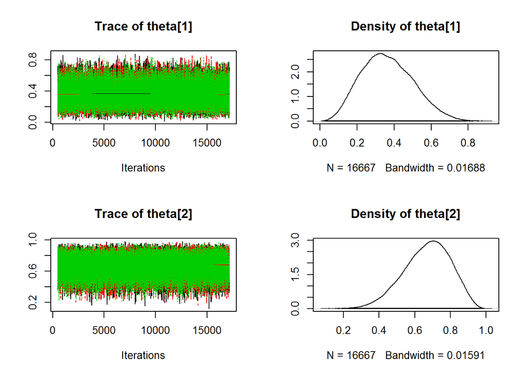

```r
plot(codaSamples)
```

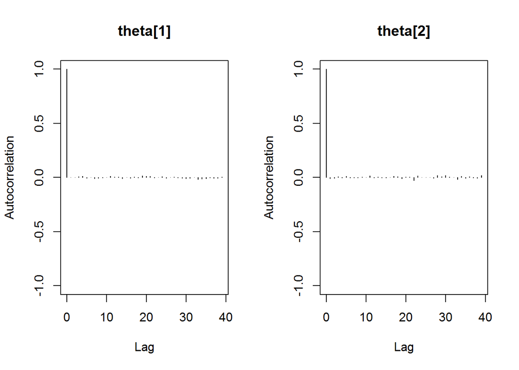

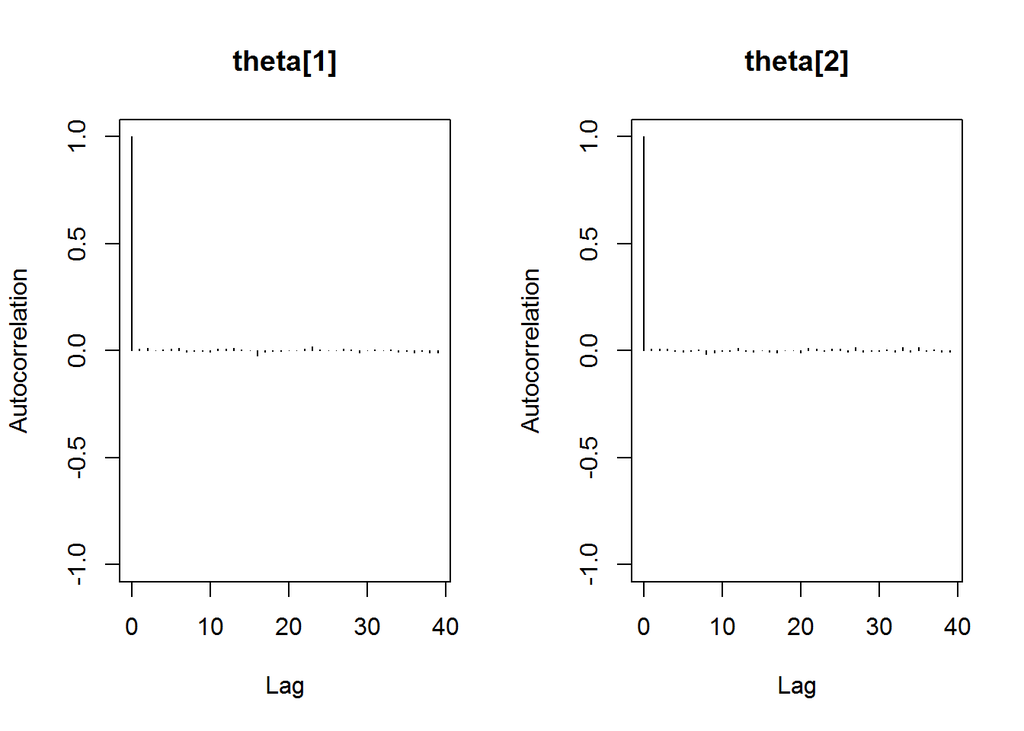

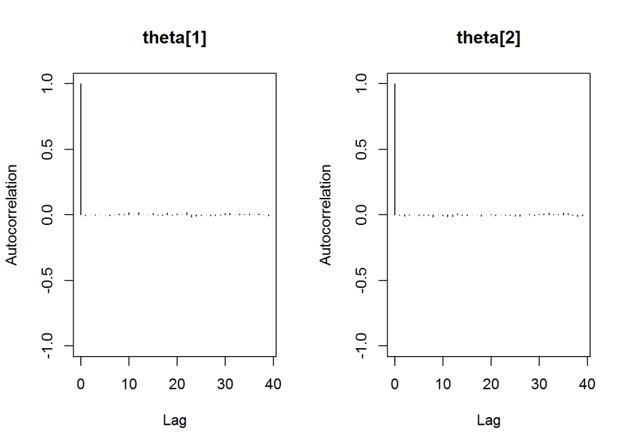

```r
autocorr.plot(codaSamples,ask=F)
```

```r
effectiveSize(codaSamples)
```

```
## theta[1] theta[2]
##    50001    50001
```

```r
gelman.diag(codaSamples)
```

```
## Potential scale reduction factors:
##
##          Point est. Upper C.I.
## theta[1]          1          1
## theta[2]          1          1
##
## Multivariate psrf
##
## 1
```

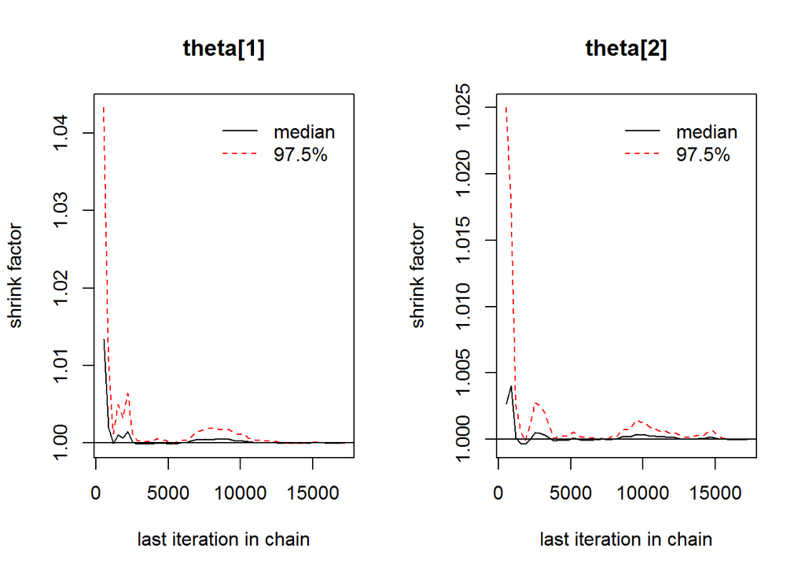

```r
gelman.plot(codaSamples)
```

Check estimated means.

```r
matrix(unlist(lapply(codaSamples,function(z) apply(z,2,mean))),ncol=3)
```

```
##           [,1]      [,2]      [,3]
## [1,] 0.3657954 0.3640742 0.3639553
## [2,] 0.6688136 0.6679356 0.6674432
```

Plot posterior densities.

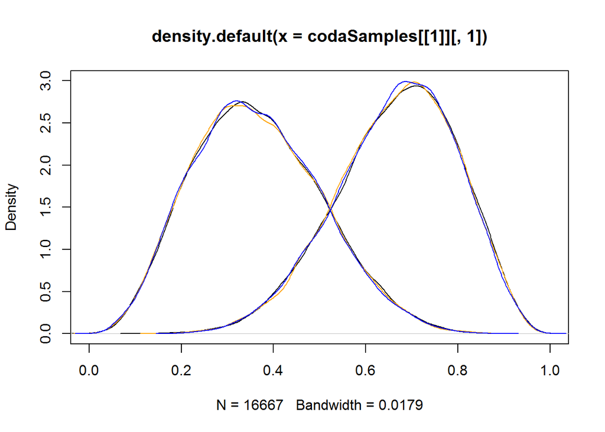

```r
plot(density(codaSamples[[1]][,1]),xlim=c(0,1),ylim=c(0,3))
lines(density(codaSamples[[1]][,2]))
lines(density(codaSamples[[2]][,1]),col="orange")
lines(density(codaSamples[[2]][,2]),col="orange")
lines(density(codaSamples[[3]][,1]),col="blue")
lines(density(codaSamples[[3]][,2]),col="blue")
```

Calculate HDIs for each chain.

```r
(HDIofChainsHierarchi<-lapply(codaSamples,function(z) cbind(Theta1=HDIofMCMC(codaSamples[[1]][,1]),                                                   Theta2=HDIofMCMC(codaSamples[[1]][,2]))))
```

```
## [[1]]
##         Theta1    Theta2
## [1,] 0.1091447 0.4132740
## [2,] 0.6343077 0.9086507
##
## [[2]]
##         Theta1    Theta2
## [1,] 0.1091447 0.4132740
## [2,] 0.6343077 0.9086507
##
## [[3]]
##         Theta1    Theta2
## [1,] 0.1091447 0.4132740
## [2,] 0.6343077 0.9086507
```

Find differences between $\theta_1$ and $\theta_2$.

```r
chainDiffs<-lapply(codaSamples,function(z) z[,2]-z[,1])
```

Find left 95% HDI boundaries for the chain differences and plot them.

```r
  (leftBounds<-unlist(lapply(chainDiffs,function(z) HDIofMCMC(z,.95)[1])))
```

```
## [1] -0.07859019 -0.07481282 -0.08488294
```

```r
  head(chainDiffs[[1]])
```

```
## Markov Chain Monte Carlo (MCMC) output:
## Start = 501
## End = 507
## Thinning interval = 1
## [1] 0.3810549 0.3239539 0.6876074 0.3563450 0.3401786 0.1329315 0.1980090
```

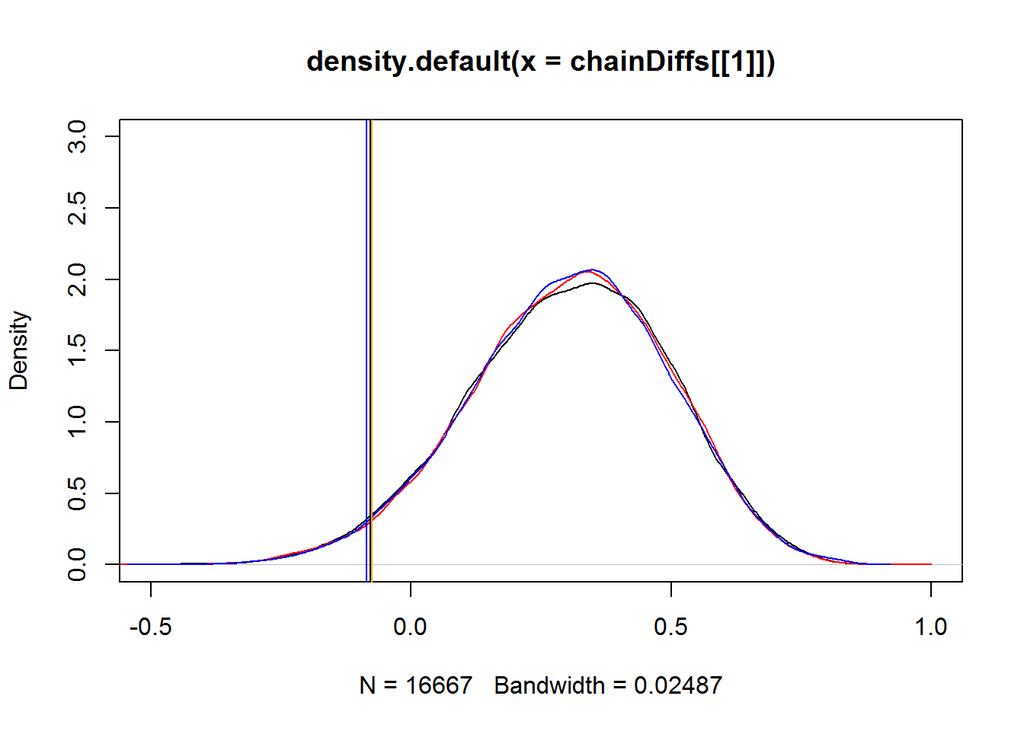

```r
  plot(density(chainDiffs[[1]]),xlim=c(-.5,1),ylim=c(0,3),col="black")
  lines(density(chainDiffs[[2]]),col="red")
  lines(density(chainDiffs[[3]]),col="blue")
  abline(v=leftBounds,col=c("black","orange","blue"))
```

For the given sample and prior distribution probabilities of success do not seem to be distinguishable by 95% HDI for all 3 chains.

**How should prior distribution change in order to make the probabilities for the two groups distinguishable?**

**Repeat calculations with different priors**.

## 5.3 Separate group models

Estimate group proportions.

### 5.3.1 Separate samples

Create 2 data lists for JAGS: one for control group and one for treated group.

(Do it yourself)

```r
myData
```

```
##    y       s
## 1  1   Treat
## 2  0   Treat
## 3  1   Treat
## 4  1   Treat
## 5  1   Treat
## 6  1   Treat
## 7  1   Treat
## 8  0   Treat
## 9  0 Control
## 10 0 Control
## 11 1 Control
## 12 0 Control
## 13 0 Control
## 14 1 Control
## 15 0 Control
```

```r
(s<-as.numeric(myData$s))
```

```
##  [1] 2 2 2 2 2 2 2 2 1 1 1 1 1 1 1
```

```r
(gr.Treat<-myData[s==2,])
```

```
##   y     s
## 1 1 Treat
## 2 0 Treat
## 3 1 Treat
## 4 1 Treat
## 5 1 Treat
## 6 1 Treat
## 7 1 Treat
## 8 0 Treat
```

```r
(y.Treat<-gr.Treat$y)
```

```
## [1] 1 0 1 1 1 1 1 0
```

```r
(Ngr.Treat<-length(y.Treat))
```

```
## [1] 8
```

```r
(gr.Contr<-myData[s==1,])
```

```
##    y       s
## 9  0 Control
## 10 0 Control
## 11 1 Control
## 12 0 Control
## 13 0 Control
## 14 1 Control
## 15 0 Control
```

```r
(y.Contr<-gr.Contr$y)
```

```
## [1] 0 0 1 0 0 1 0
```

```r
(Ngr.Contr<-length(y.Contr))
```

```
## [1] 7
```

```r
#Calculate MLE means
(MLE.meanTreat<-sum(y.Treat)/Ngr.Treat)
```

```
## [1] 0.75
```

```r
(MLE.meanContr<-sum(y.Contr)/Ngr.Contr)
```

```
## [1] 0.2857143
```

```r
#Create data lists
(dataList.Treat<-list(y=y.Treat,Ntotal=Ngr.Treat))
```

```
## $y
## [1] 1 0 1 1 1 1 1 0
##
## $Ntotal
## [1] 8
```

```r
(dataList.Contr<-list(y=y.Contr,Ntotal=Ngr.Contr))
```

```
## $y
## [1] 0 0 1 0 0 1 0
##
## $Ntotal
## [1] 7
```

### 5.3.2 Create model description

Create one model description that works for both groups.

(Do it yourself)

```r
modelString.SingleModel="
model {
  for (i in 1:Ntotal) {
    y[i]~dbern(theta)
  }
  theta~dbeta(1,1) #Consider different parameterizations of prior
}
"
writeLines( modelString.SingleModel , con="TEMPmodelSingle.txt" )
```

### 5.3.3 Initialize function

Create function that randomly initializes chains near MLE.

(Do it yourself)

```r
initsList = function() {
  resampledY = sample(y, replace=TRUE ) # resample
  thetaInit = sum(resampledY)/length(resampledY)
  thetaInit = 0.001+0.998*thetaInit # keep away from 0,1
  return( list( theta=thetaInit ) )
}
```

Check initiation:

```r
initsList()
```

```
## $theta
## [1] 0.5998
```

### 5.3.4 Run MCMC for the control group

Create JAGS model, run burn in and simulate Markov chains for the control group.

(Do it yourself)

```r
#Create model Contr
jagsModel.Contr<-jags.model(file="TEMPmodelSingle.txt",data=dataList.Contr,
                            n.chains=3,n.adapt=500)
#Update Contr
update(jagsModel.Contr,n.iter=600)

#Run Contr
codaSamples.Contr<-coda.samples(jagsModel.Contr,variable.names=c("theta"),n.iter=3334)
list.samplers(jagsModel.Contr)
```

```
## $`bugs::ConjugateBeta`
## [1] "theta"
```

Analyze the chains.

Asses convergence.

```r
#Analyze Contr
summary(codaSamples.Contr)
```

```
##
## Iterations = 601:3934
## Thinning interval = 1
## Number of chains = 3
## Sample size per chain = 3334
##
## 1. Empirical mean and standard deviation for each variable,
##    plus standard error of the mean:
##
##           Mean             SD       Naive SE Time-series SE
##       0.331978       0.150004       0.001500       0.001469
##
## 2. Quantiles for each variable:
##
##    2.5%     25%     50%     75%   97.5%
## 0.08115 0.21617 0.32032 0.43157 0.64932
```

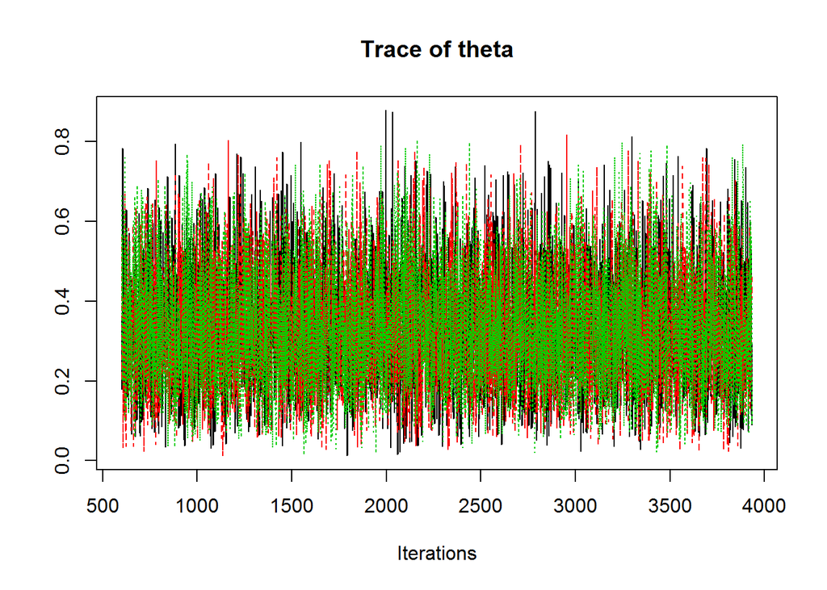

```r
coda::traceplot(codaSamples.Contr)
```

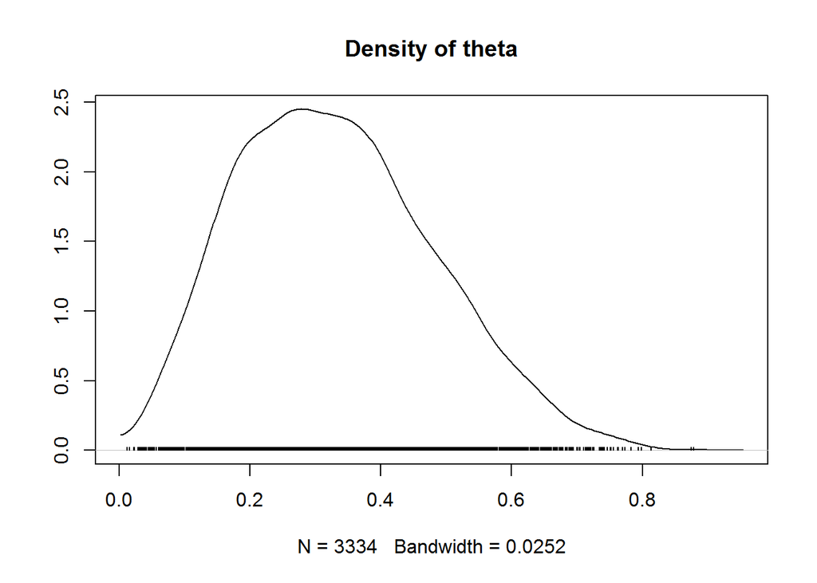

```r
densplot(codaSamples.Contr)
```

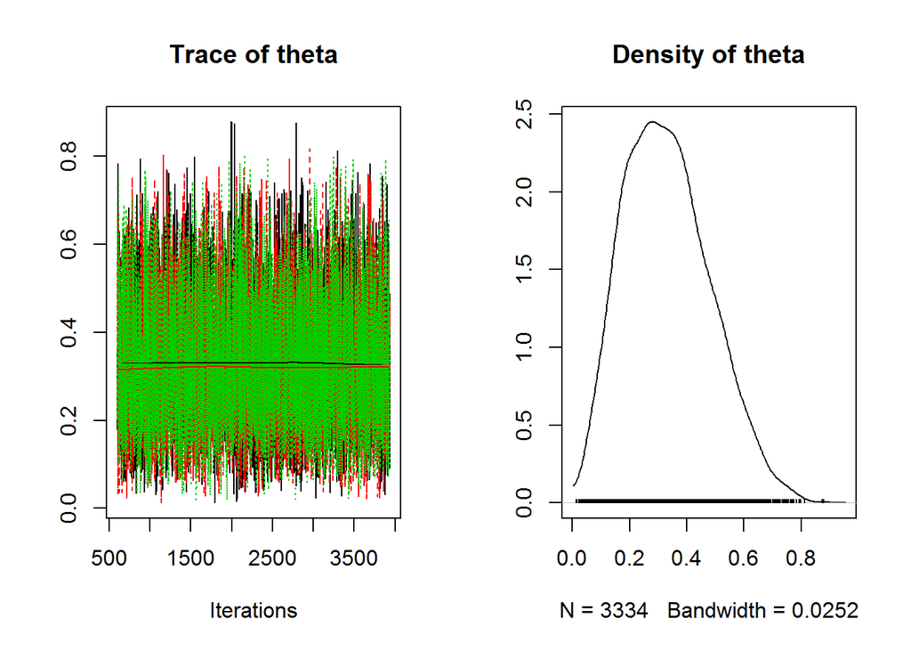

```r
plot(codaSamples.Contr)
```

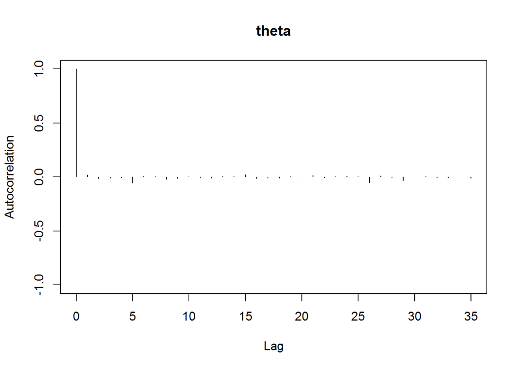

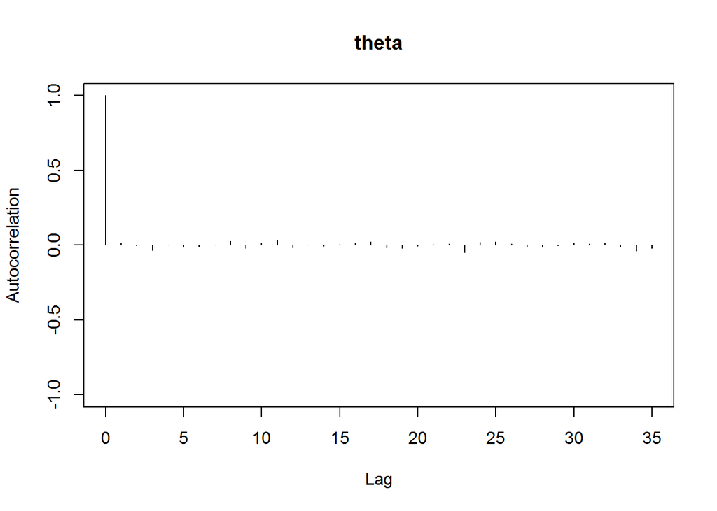

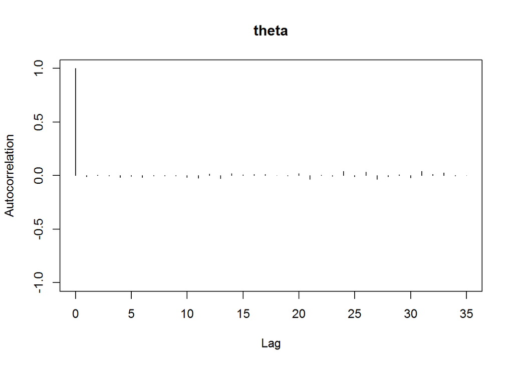

```r
autocorr.plot(codaSamples.Contr,ask=F)
```

```r
effectiveSize(codaSamples.Contr)
```

```
##    theta
## 10456.07
```

```r
gelman.diag(codaSamples.Contr)
```

```
## Potential scale reduction factors:
##
##       Point est. Upper C.I.
## theta          1          1
```

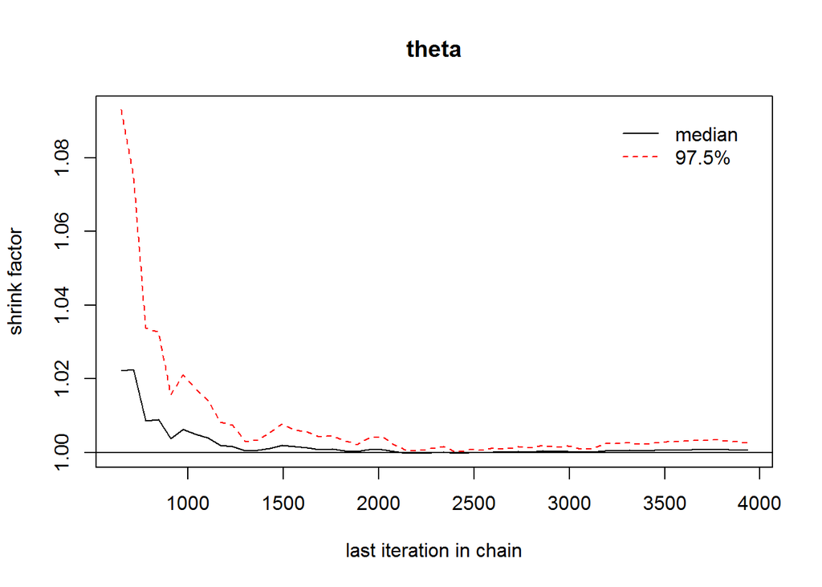

```r
gelman.plot(codaSamples.Contr)
```

Find mean values of the parameter.

```r
lapply(codaSamples.Contr,mean)
```

```
## [[1]]
## [1] 0.3364224
##
## [[2]]
## [1] 0.3272179
##
## [[3]]
## [1] 0.3322933
```

Create histograms.

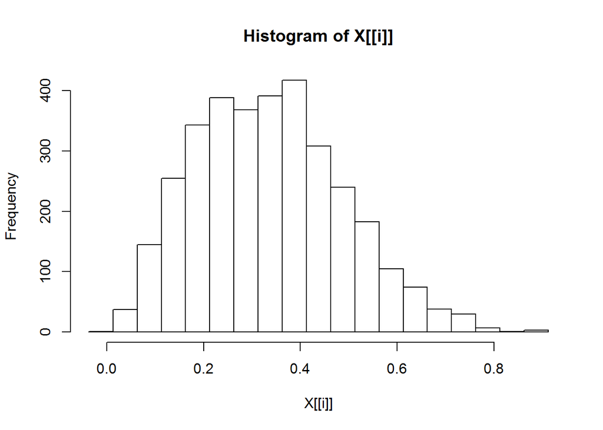

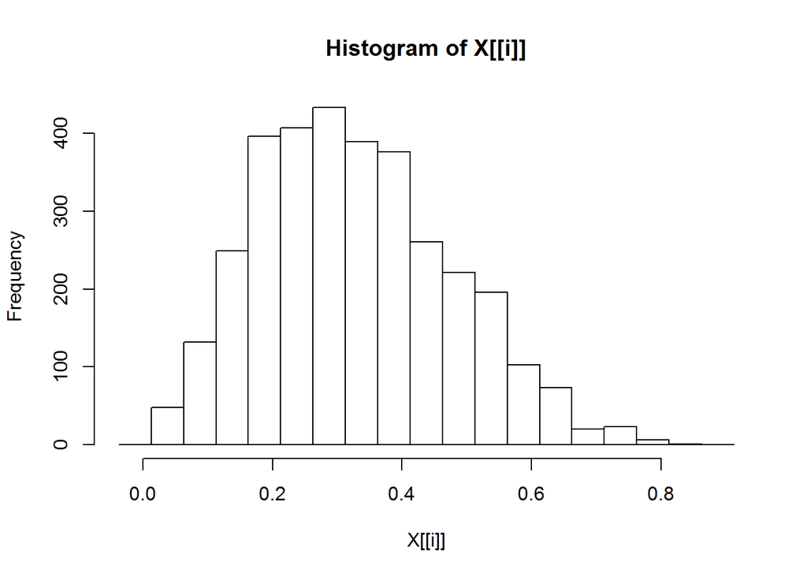

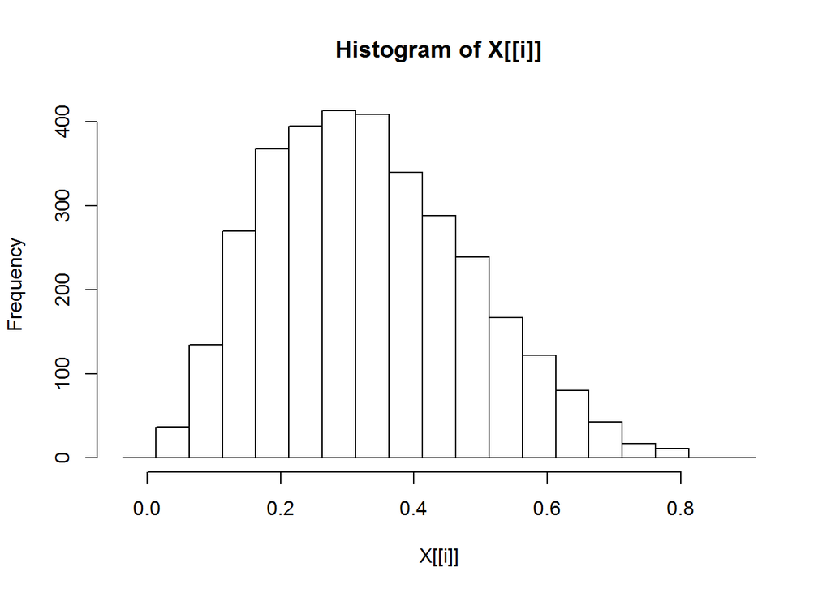

```r
l<-min(unlist(codaSamples.Contr))-.05
h<-max(unlist(codaSamples.Contr))+.05
histBreaks<-seq(l,h,by=.05)
postHist.Contr<-lapply(codaSamples.Contr,hist,breaks=histBreaks)
```

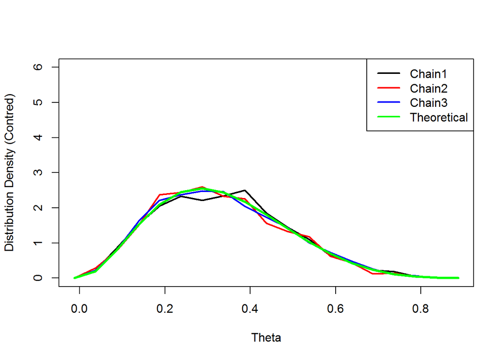

```r
plot(postHist.Contr[[1]]$mids,postHist.Contr[[1]]$density,type="l",col="black",lwd=2,ylim=c(0,6),ylab="Distribution Density (Contred)",xlab="Theta")
lines(postHist.Contr[[2]]$mids,postHist.Contr[[2]]$density,type="l",col="red",lwd=2)
lines(postHist.Contr[[3]]$mids,postHist.Contr[[3]]$density,type="l",col="blue",lwd=2)
lines(postHist.Contr[[3]]$mids,dbeta(postHist.Contr[[3]]$mids,1+sum(y.Contr),Ngr.Contr-sum(y.Contr)+1),
      type="l",col="green",lwd=3)
legend("topright",legend=c("Chain1","Chain2","Chain3","Theoretical"),col=c("black","red","blue","green"),lwd=2)
```

### 5.3.5 Run MCMC for the treated group

(Do it yourself)

```r
#Create model Treat
jagsModel.Treat<-jags.model(file="TEMPmodelSingle.txt",data=dataList.Treat,
                            n.chains=3,n.adapt=500)
#Update Treat
update(jagsModel.Treat,n.iter=600)

#Run Treat
codaSamples.Treat<-coda.samples(jagsModel.Treat,variable.names=c("theta"),n.iter=3334)
list.samplers(jagsModel.Treat)
```

```
## $`bugs::ConjugateBeta`
## [1] "theta"
```

Analyze the chains.

Asses convergence.

```r
#Analyze Treat
summary(codaSamples.Treat)
```

```
##
## Iterations = 601:3934
## Thinning interval = 1
## Number of chains = 3
## Sample size per chain = 3334
##
## 1. Empirical mean and standard deviation for each variable,
##    plus standard error of the mean:
##
##           Mean             SD       Naive SE Time-series SE
##       0.702028       0.138948       0.001389       0.001389
##
## 2. Quantiles for each variable:
##
##   2.5%    25%    50%    75%  97.5%
## 0.4006 0.6094 0.7163 0.8081 0.9283
```

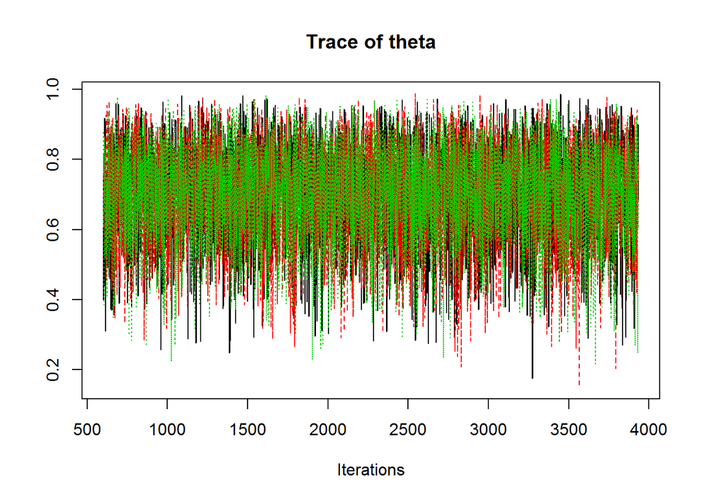

```r
coda::traceplot(codaSamples.Treat)
```

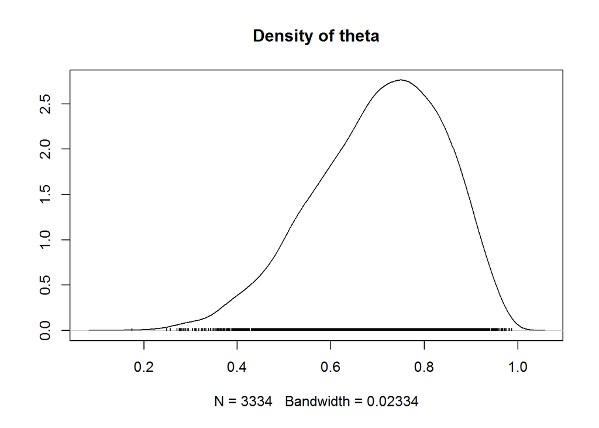

```r
densplot(codaSamples.Treat)
```

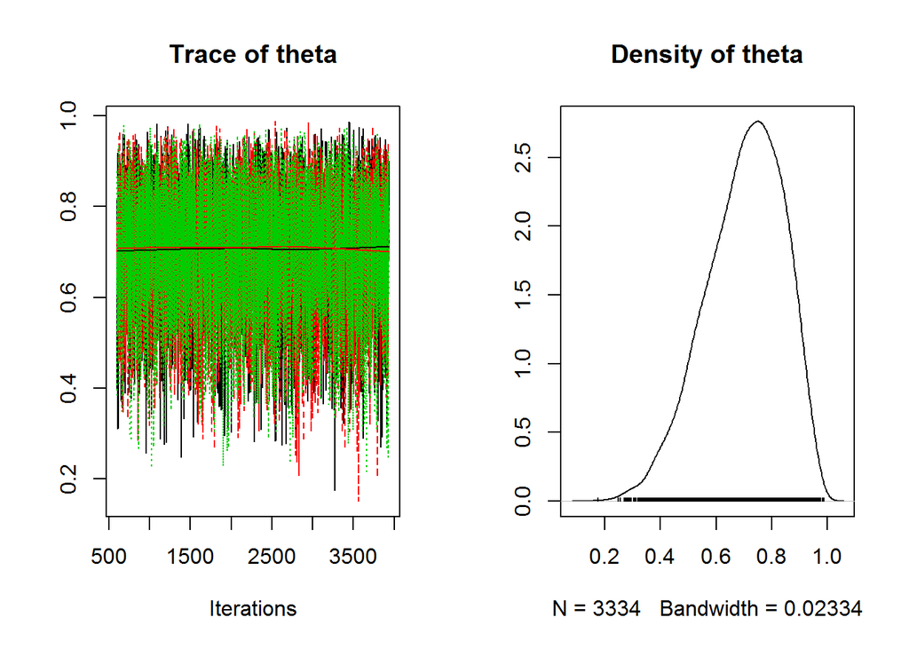

```r
plot(codaSamples.Treat)
```